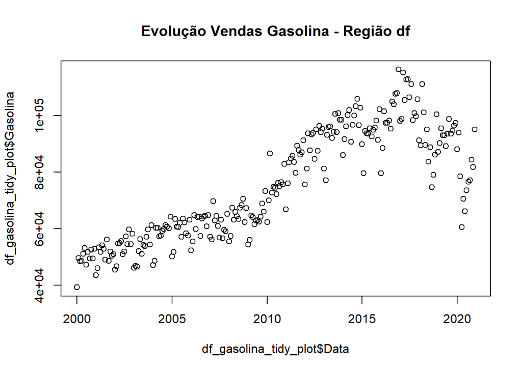

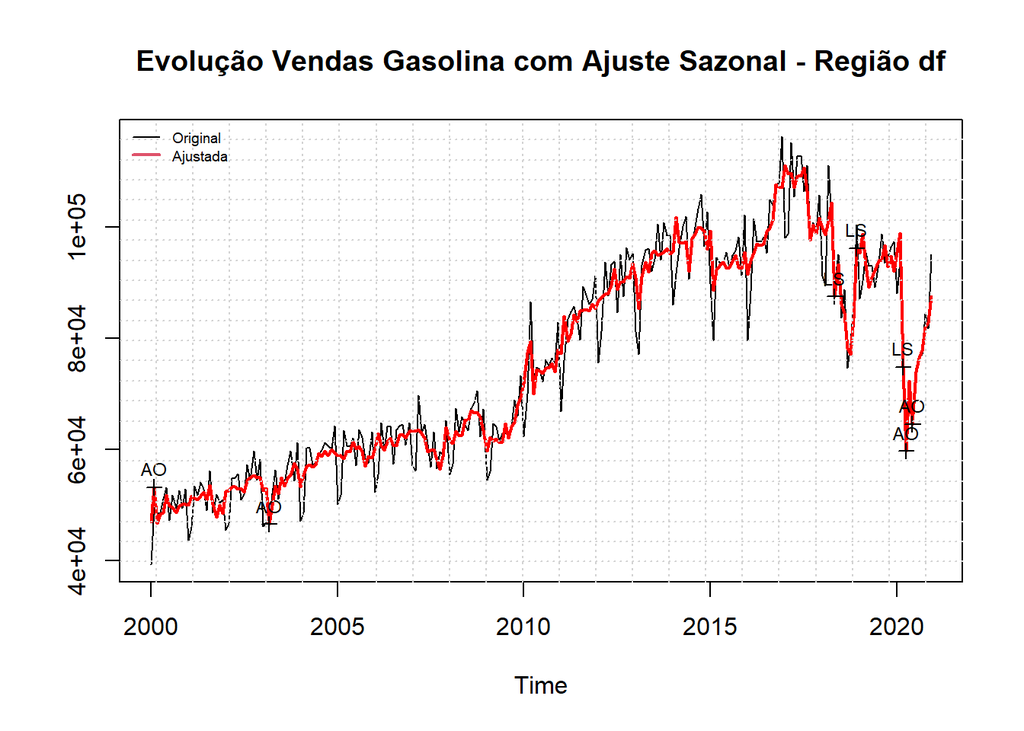

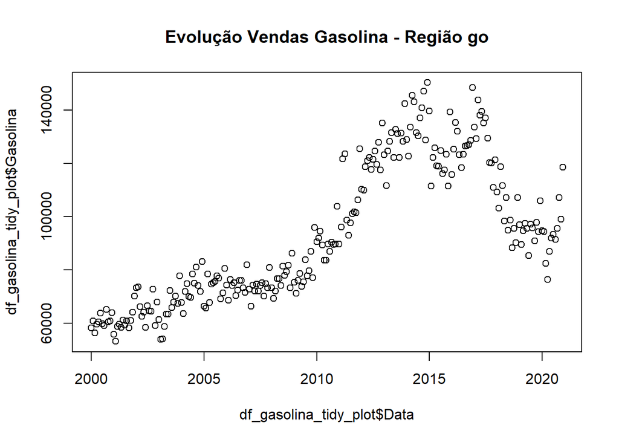

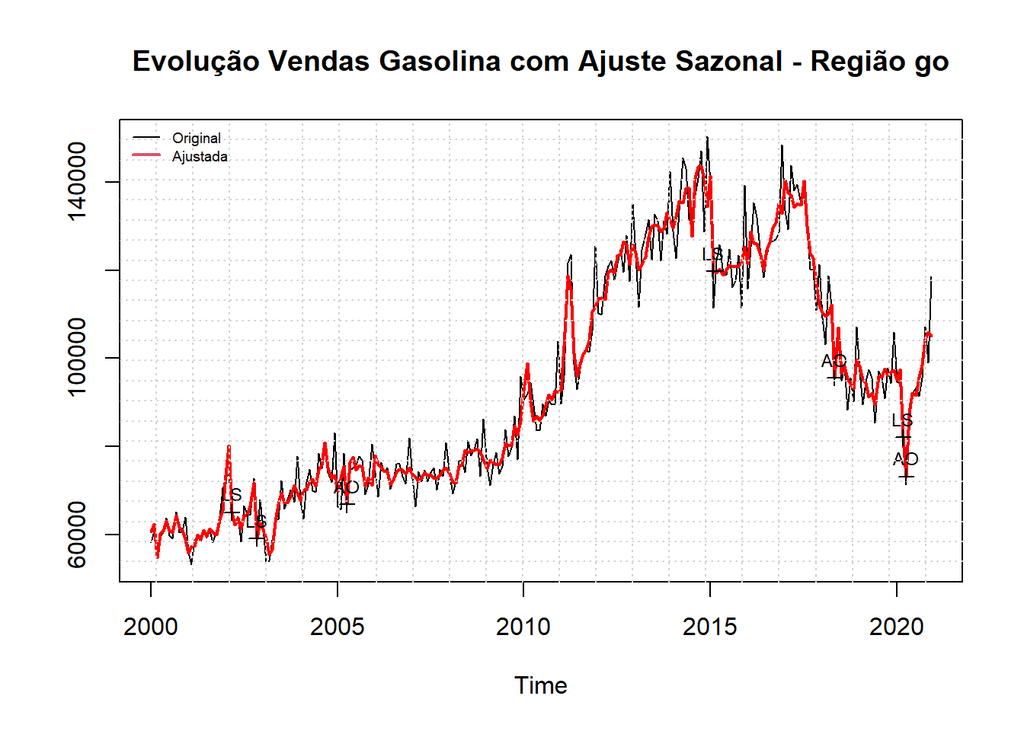

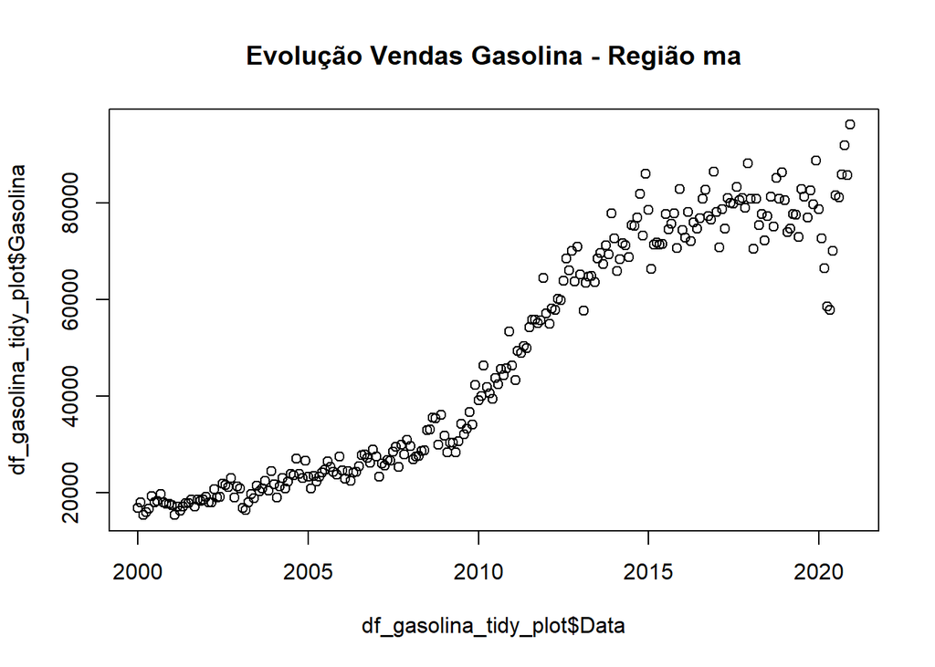

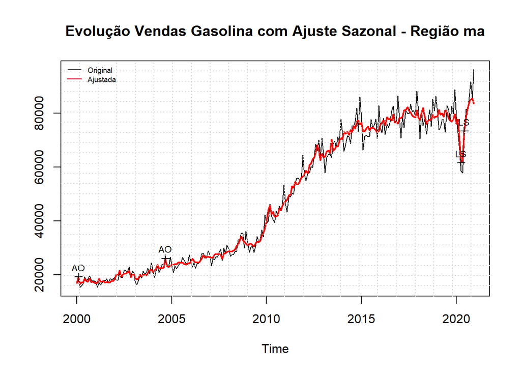

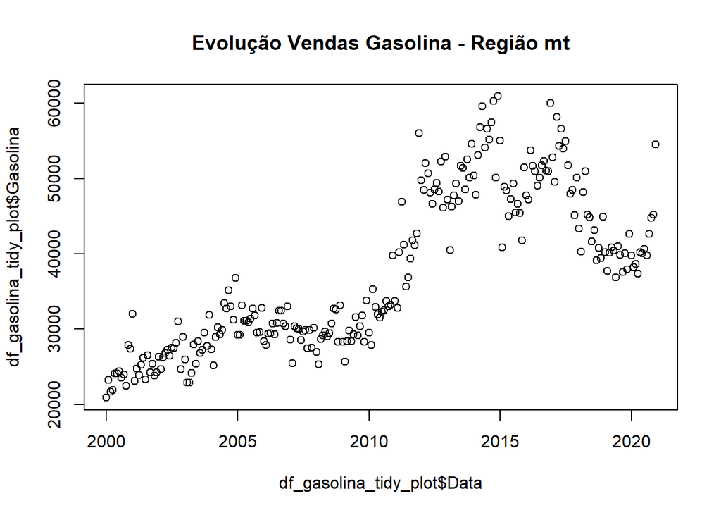

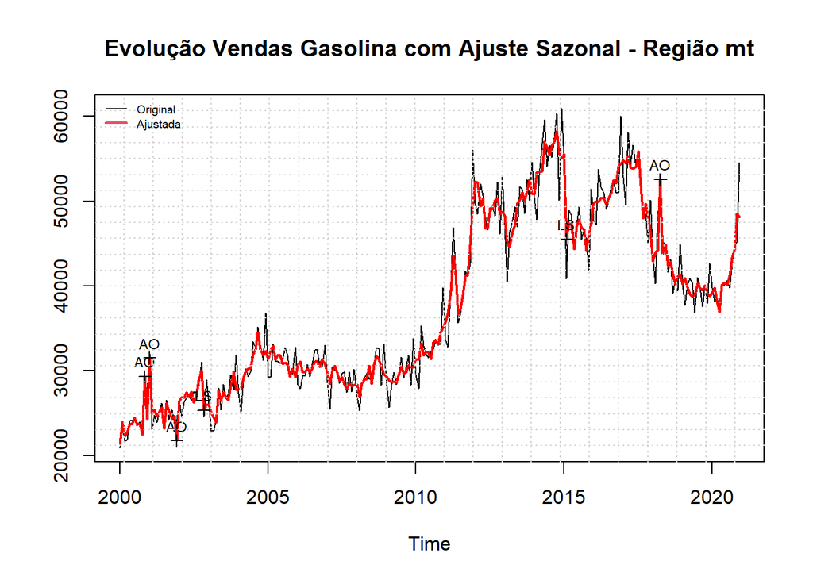

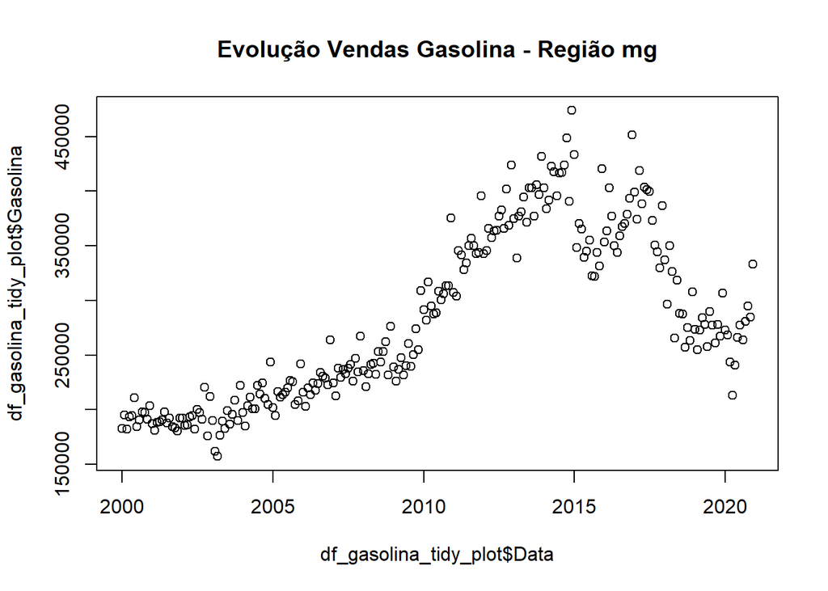

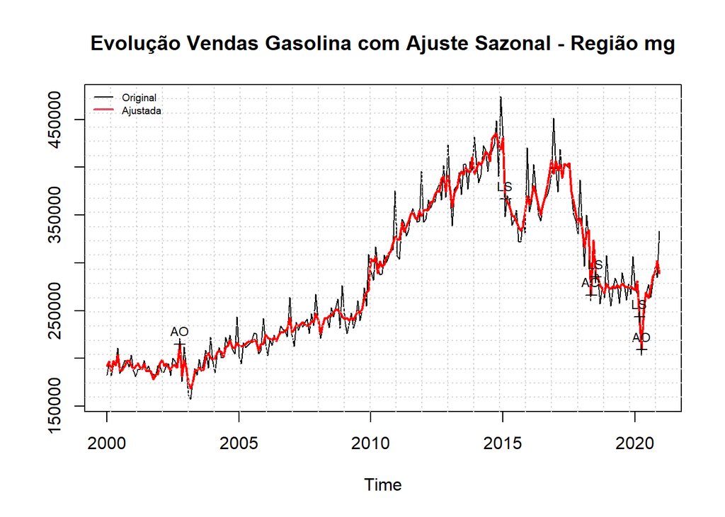

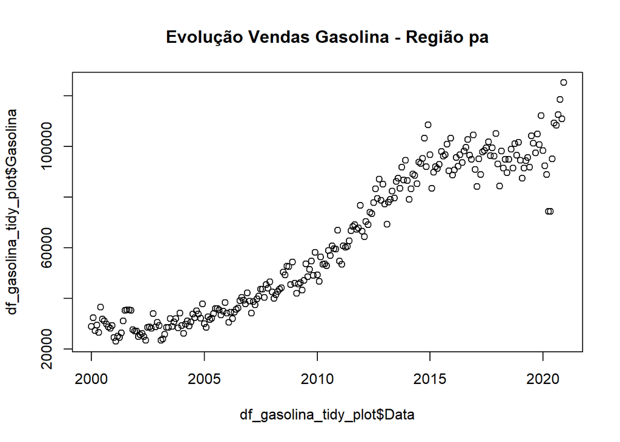

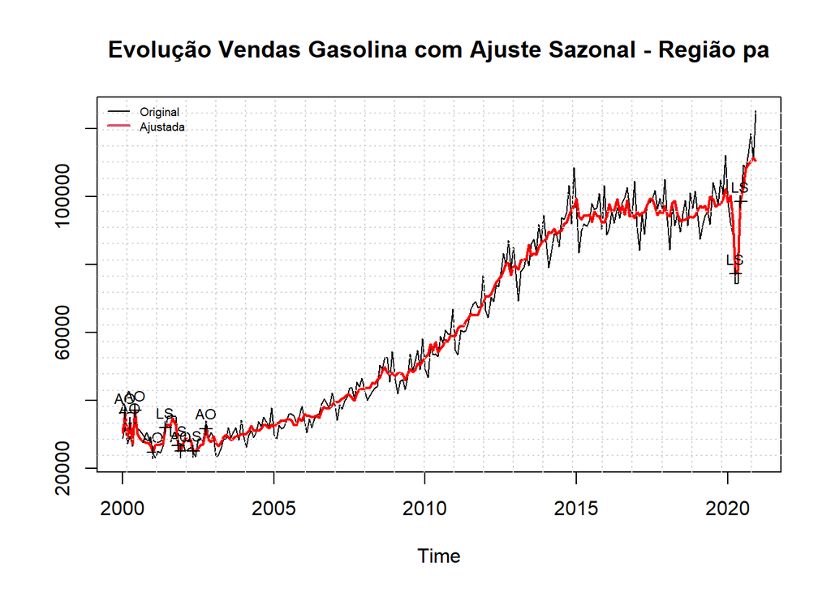

[6 more figures not shown]

```r
#Por região: série original vs ajuste sazonal (Gasolina)
for (i in unique(df_gasolina_tidy$regiao)) {
  df_gasolina_tidy_plot <- df_gasolina_tidy %>% filter(regiao == i)
  plot(df_gasolina_tidy_plot$Data, df_gasolina_tidy_plot$Gasolina, main = paste("Evolução Vendas Gasolina - Região", i, sep = " "))

  regiao_br <- ts(df_gasolina_tidy_plot$Gasolina, start = c(2000, 1) , frequency = 12)
  dessaz_br <- seas(regiao_br, x11 = "")
  plot(dessaz_br, main = paste("Evolução Vendas Gasolina com Ajuste Sazonal - Região", i, sep = " "))
  grid(nx = 23)
  legend("topleft", legend = c("Original", "Ajustada"), col = c(1, 2), lwd = c(1, 2),
         lty = 1, bty = "n", cex = 0.6)
}
```

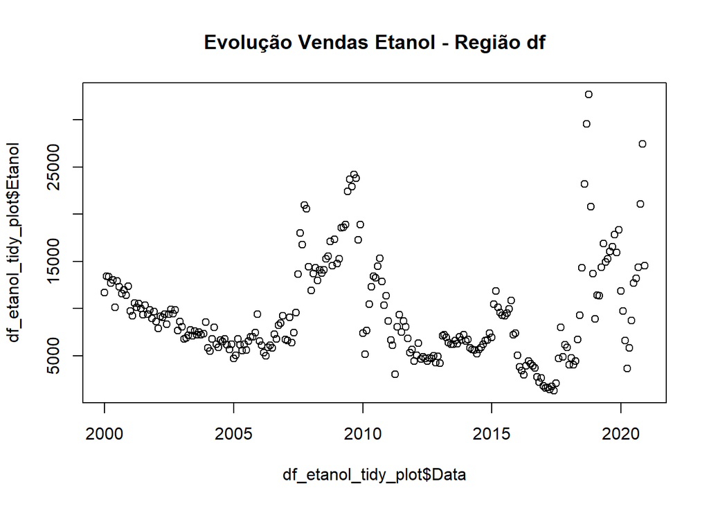

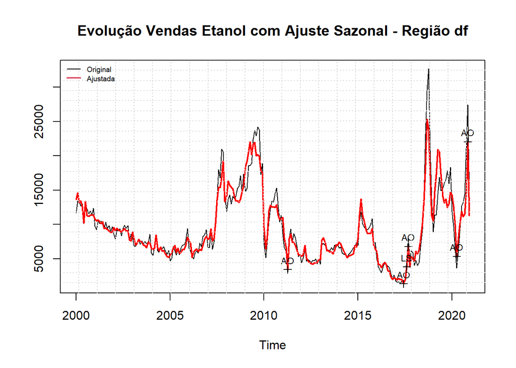

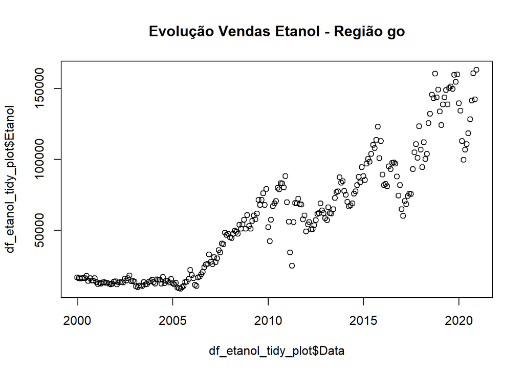

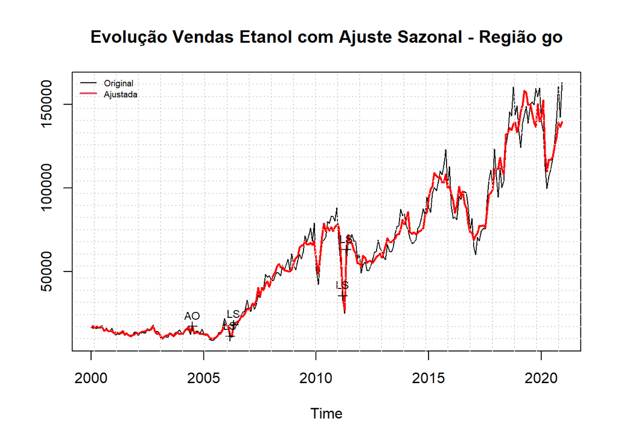

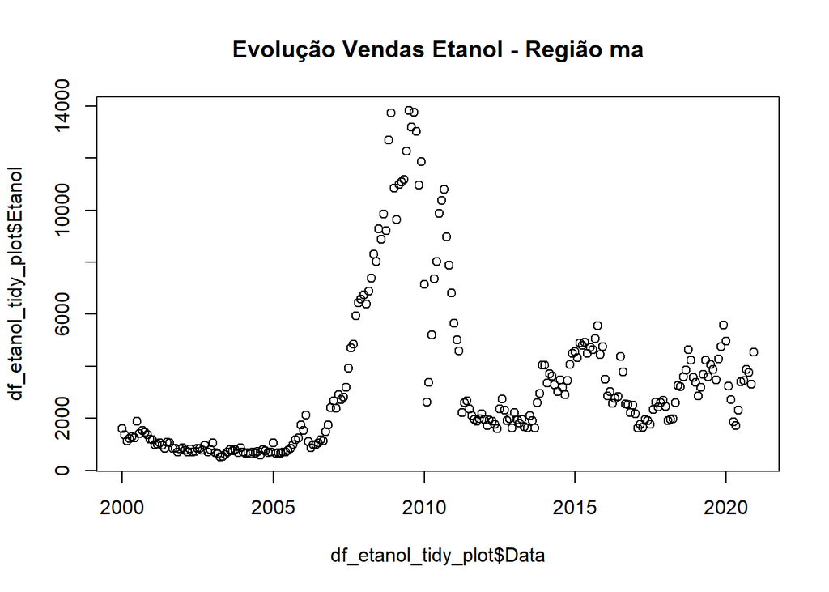

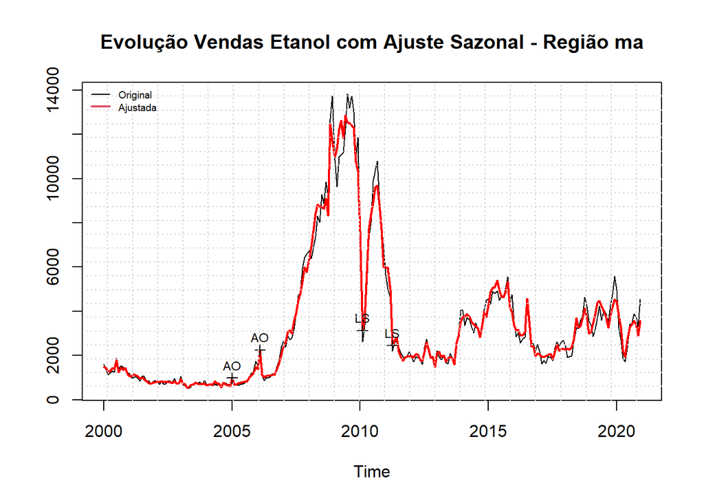

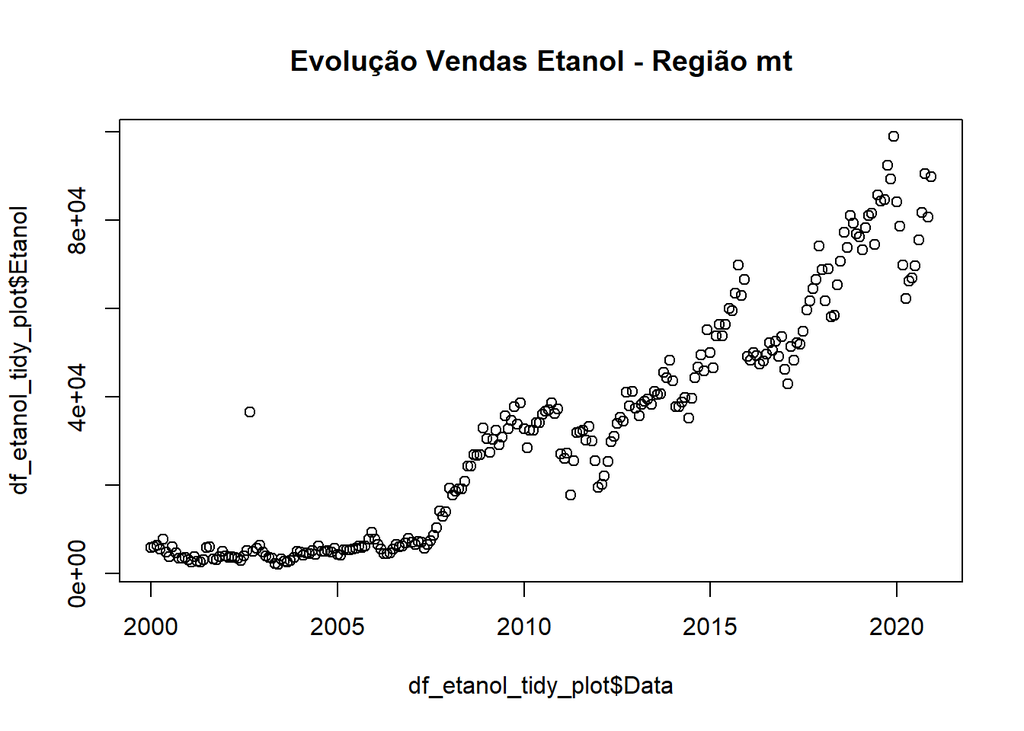

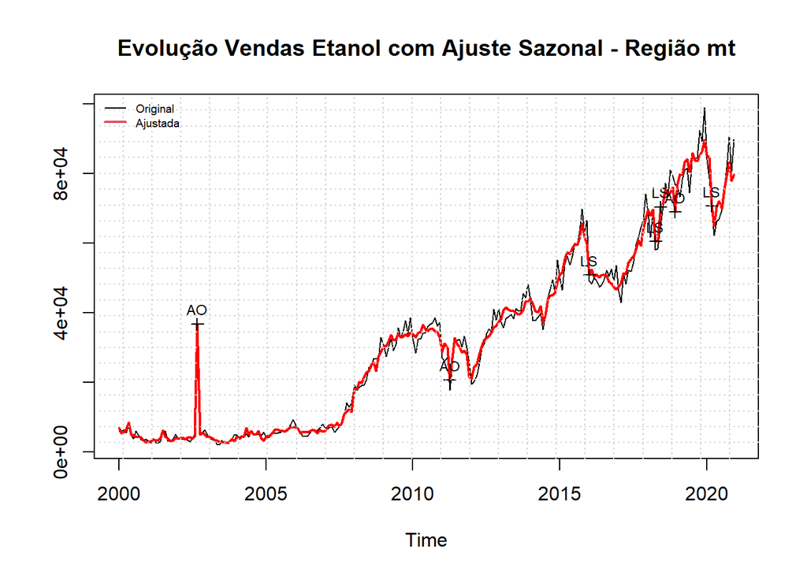

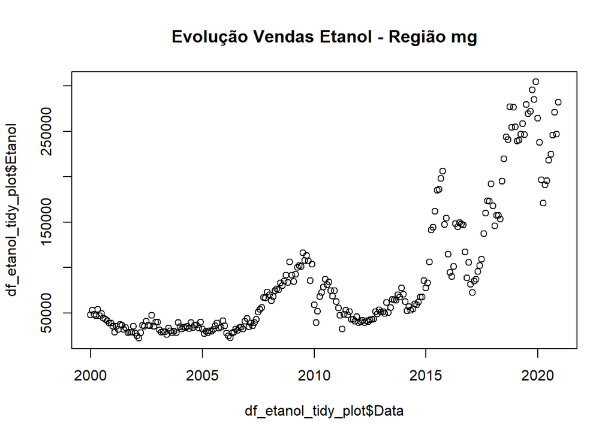

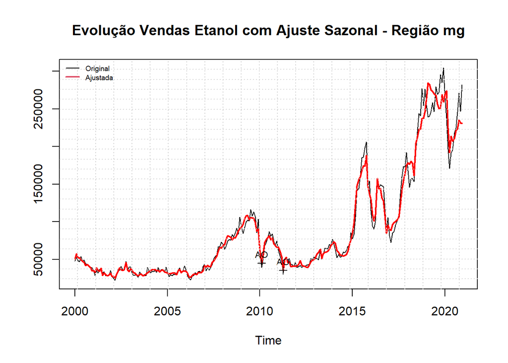

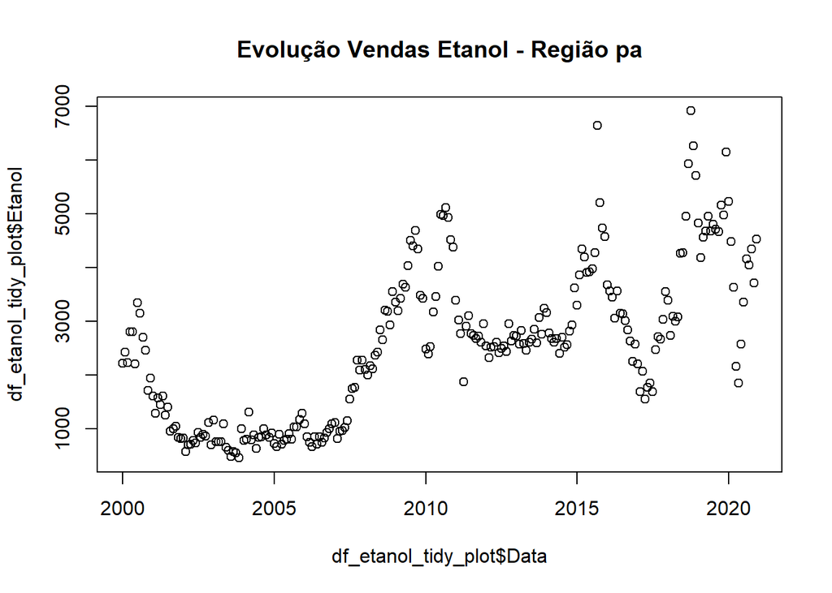

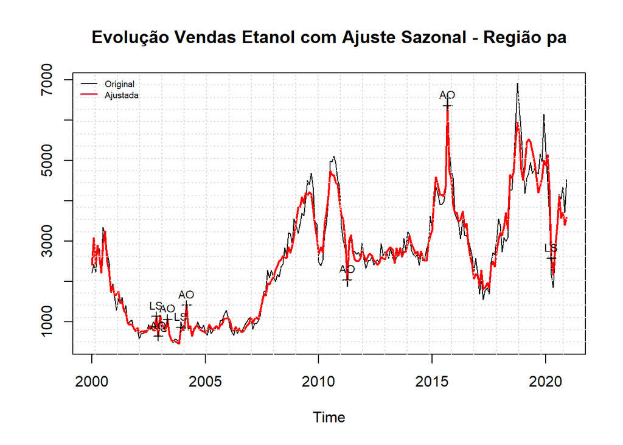

[6 more figures not shown]

```r
#Por região: série original vs ajuste sazonal (Gasolina)
for (i in unique(df_etanol_tidy$regiao)) {
  df_etanol_tidy_plot <- df_etanol_tidy %>% filter(regiao == i)
  plot(df_etanol_tidy_plot$Data, df_etanol_tidy_plot$Etanol, main = paste("Evolução Vendas Etanol - Região", i, sep = " "))

  regiao_br <- ts(df_etanol_tidy_plot$Etanol, start = c(2000, 1) , frequency = 12)
  dessaz_br <- seas(regiao_br, x11 = "")
  plot(dessaz_br, main = paste("Evolução Vendas Etanol com Ajuste Sazonal - Região", i, sep = " "))
  grid(nx = 23)
  legend("topleft", legend = c("Original", "Ajustada"), col = c(1, 2), lwd = c(1, 2),
         lty = 1, bty = "n", cex = 0.6)
}
```

— Abaixo, encontra-se a distribuição dos tipos de combustível por estado. Analisandos os gráficos de barra, pode-se concluir que as vendas de combustível são maiores no estado de São Paulo, seguido por Minas Gerais.

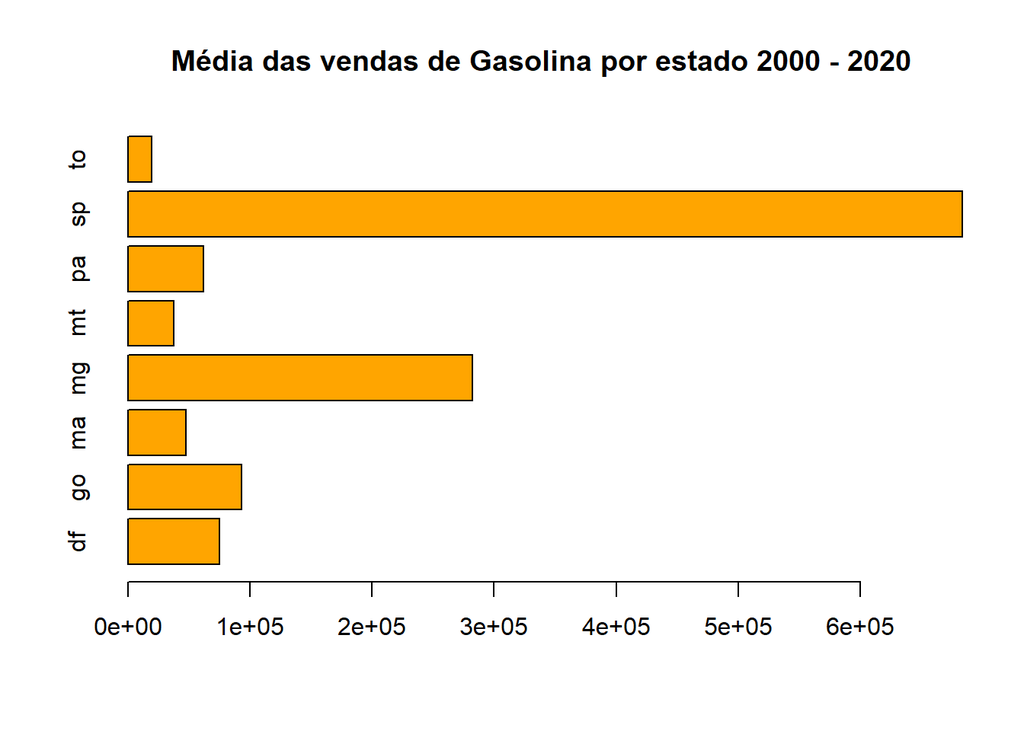

```r
#Consumo de Gasolina por estado média dos últimos 20 anos
df_gasolina_tidy_semBR <- df_gasolina_tidy %>% filter(!regiao == "br")
barplot(tapply(df_gasolina_tidy_semBR$Gasolina, df_gasolina_tidy_semBR$regiao, mean),
        col = "orange", horiz = T, main = "Média das vendas de Gasolina por estado 2000 - 2020")
```

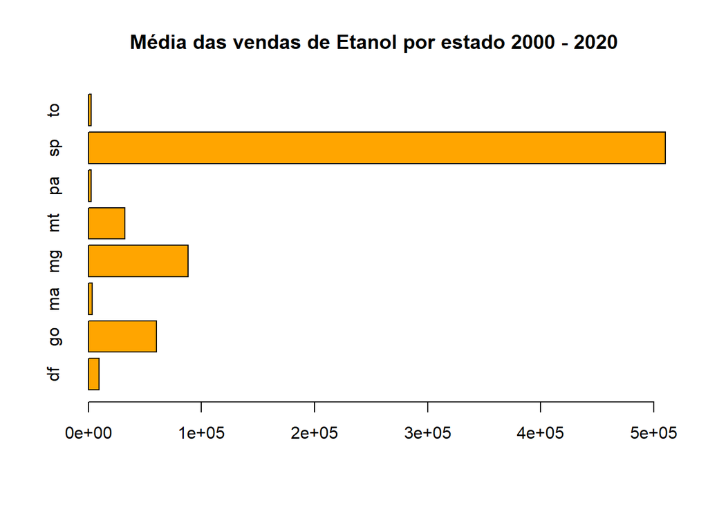

```r
#Consumo de Etanol por estado, média dos últimos 20 anos
df_etanol_tidy_semBR <- df_etanol_tidy %>% filter(!regiao == "br")
barplot(tapply(df_etanol_tidy_semBR$Etanol, df_etanol_tidy_semBR$regiao, mean),
        col = "orange", horiz = T, main = "Média das vendas de Etanol por estado 2000 - 2020")
```

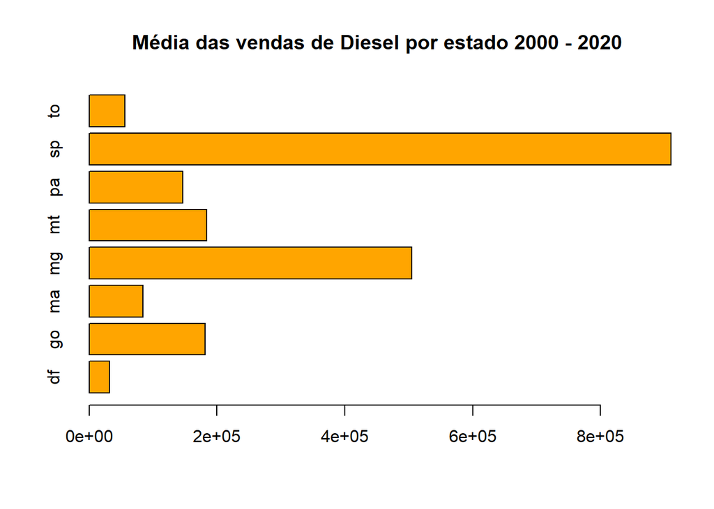

```r
#Consumo de Diesel por estado média dos últimos 20 anos
df_diesel_tidy_semBR <- df_diesel_tidy %>% filter(!regiao == "br")
barplot(tapply(df_diesel_tidy_semBR$Diesel, df_diesel_tidy_semBR$regiao, mean),
        col = "orange", horiz = T, main = "Média das vendas de Diesel por estado 2000 - 2020")
```

— O tamanho total médio do mercado nos útlimos 20 anos é de 7.584.254 metros cúbicos de combustíveis. Além disso, analisando o a evolução do mercado nos últimos 5 anos pode-se notar uma tendência positiva, mesmo com o impacto da pandemia de COVID-19 em 2020.

```r
#Analisando o tamanho total do mercado e a evolução deste nos últimos 5 anos#
df_consolidado <- full_join(x = df_diesel_tidy, y = df_gasolina_tidy)
df_consolidado <- full_join(x = df_consolidado, y = df_etanol_tidy)
```

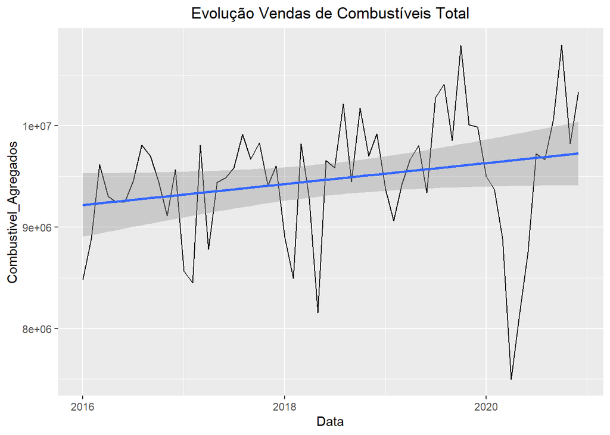

```r
df_consolidado_tidy_BR <- df_consolidado %>% filter(regiao == "br")
df_tamanho_do_mercado <- df_consolidado_tidy_BR %>% group_by(Data) %>% summarise(Combustivel_Agregados=sum(Diesel, Gasolina, Etanol))

ggplot(df_tamanho_do_mercado %>% filter(Data >= "2016-01-01"), aes(Data, Combustivel_Agregados)) +
  geom_line() + geom_smooth(method = lm) + ggtitle("Evolução Vendas de Combustíveis Total") + theme(plot.title = element_text(hjust = 0.5))
```

```r
mean(df_tamanho_do_mercado$Combustivel_Agregados)
```

```
## [1] 7584254
```

```
library(rmarkdown)
render("case4intelligence.Rmd")
```

```r
library(seasonal)
```